# Metropolis: road volume on 2024-10-18

## Source and measurement

The source is the saved City-traffic-M payload for Yekaterinburg on 2024-10-18, from `mightyneghbor/city-traffic-benchmarks`, source version 4. The source files are `city-traffic-M-raw-volume.parquet` and `city-traffic-M-raw-static-features.parquet`. The bundled cache retains the 720 supplied segment records and the saved volume arrays from `city_traffic_M_osm_congestion_sample.json`.

Each saved frame represents the source’s mean of three five-minute observations. The preparation performs no further temporal aggregation or segment selection. The physical volume unit is not established by this payload, so values retain the label `source volume`; they are not converted to vehicles/hour or capacity ratios. No speed-derived congestion index is used.

## Data preparation

`data/source.rds` contains the selected source-level records and supplied geometry. `prepare.R` converts them to the common input without downloading data. Its executed implementation appears in Appendix A. The generated `data/input.rds` is then read by the common package.

```r
library(bdynets)
source("prepare.R")
prepared_file <- prepare_example(".")
x <- read_traffic(prepared_file)
input <- readRDS(prepared_file)
index <- match(params$time_label,sub("^.* ","",x$time_labels))
stopifnot(!is.na(index))
```

The map starts at 2024-10-18 08:00 and covers 15 minutes. The default 08:00 is a demonstration selection, not a maximum-based selection. Numeric seconds and displayed labels retain the supplied source clock; they do not establish a UTC offset.

```r
knitr::kable(data.frame(
  Item=c("Roads","Frames","First interval start","Last interval start","Flow unit"),
  Value=c(nrow(x$roads),length(x$times),x$time_labels[1],tail(x$time_labels,1),x$unit)),
  caption="Data scope")
```

Data scope

| Item | Value |
| --- | --- |
| Roads | 720 |
| Frames | 96 |
| First interval start | 2024-10-18 00:00 |
| Last interval start | 2024-10-18 23:45 |
| Flow unit | source volume |

| Common field | Meaning |
| --- | --- |
| road_id | Unique directed road or segment identifier |
| geometry | Longitude/latitude vertex matrix, ordered in travel direction |
| time | Source-clock interval start in numeric seconds |
| flow | Supplied nonnegative measurement; zero is observed and NA is missing |
| unit | Supplied measurement label, without inferred conversion |

```r
knitr::kable(head(input$flow),caption="Actual prepared flow records")
```

Actual prepared flow records

| road_id | time | flow |
| --- | --- | --- |
| 21263 | 1729209600 | 4.67 |
| 21264 | 1729209600 | 5.00 |
| 34420 | 1729209600 | 4.67 |
| 3281 | 1729209600 | 5.33 |
| 3282 | 1729209600 | 5.33 |
| 3558 | 1729209600 | 5.00 |

## Whole-day coverage

```r
knitr::kable(data.frame(
  Statistic=c("Expected road-time cells","Observed cells","Missing cells","Observed zero cells"),
  Value=c(length(x$values),sum(!is.na(x$values)),sum(is.na(x$values)),sum(x$values==0,na.rm=TRUE))),
  caption="All supplied roads and intervals")
```

All supplied roads and intervals

| Statistic | Value |
| --- | --- |
| Expected road-time cells | 69120 |
| Observed cells | 69120 |
| Missing cells | 0 |
| Observed zero cells | 11577 |

A road-time cell is one road in one interval. These counts cover the whole day, including roads outside the central-area map view. An omitted pair and an explicit NA are missing; neither is replaced by zero.

## Selected-time map and statistics

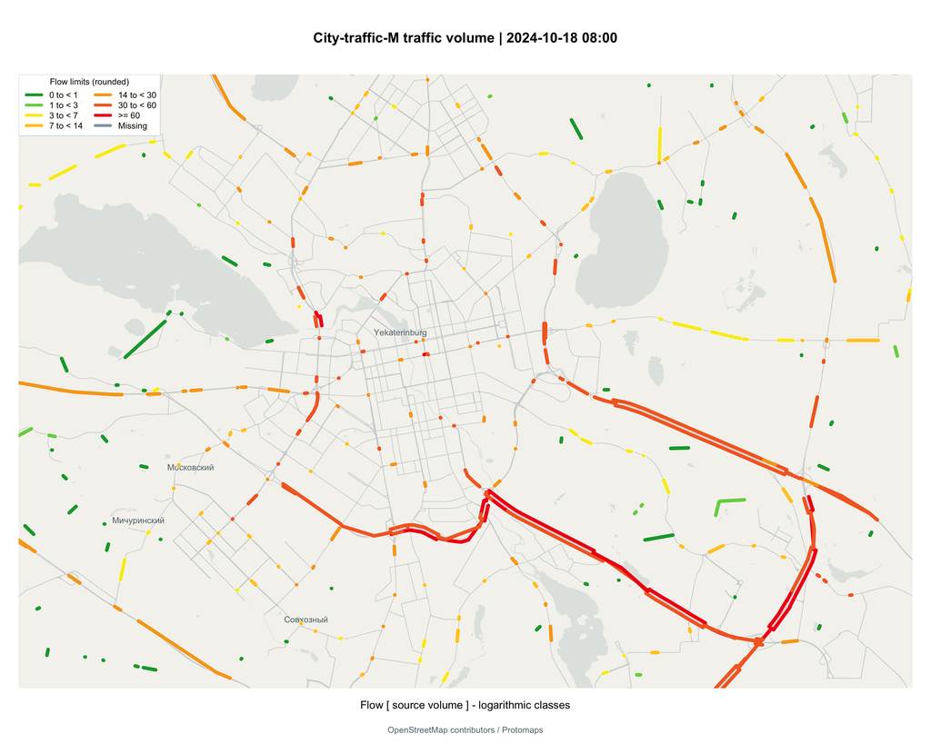

Saved source-volume observations at the selected fifteen-minute interval. The map focuses on the central spatial range; all 720 supplied segments enter the statistics.

```r
plot(x,index=index)
```

The common log1p algorithm uses all supplied values to establish the day’s thresholds. Red means higher source volume, not a verified congested state. Speed-limit and maximum-volume attributes do not choose a plotting style.

```r
selected <- traffic_summary(x,index=index)
knitr::kable(selected[c("time","roads","available","missing","zero")],
  caption="Selected-interval availability")
```

Selected-interval availability

| time | roads | available | missing | zero |
| --- | --- | --- | --- | --- |
| 2024-10-18 08:00 | 720 | 720 | 0 | 82 |

```r
knitr::kable(selected[c("minimum","median","mean","p95","maximum")],
  digits=2,caption=paste("Selected-interval distribution [",x$unit,"]"))
```

Selected-interval distribution [ source volume ]

| minimum | median | mean | p95 | maximum |
| --- | --- | --- | --- | --- |
| 0 | 21.67 | 26.95 | 68.33 | 89 |

At 2024-10-18 08:00, mean source volume is 26.95 and the median is 21.67. There are 82 observed zero values and 0 missing values in this interval.

## Daily pattern and limits

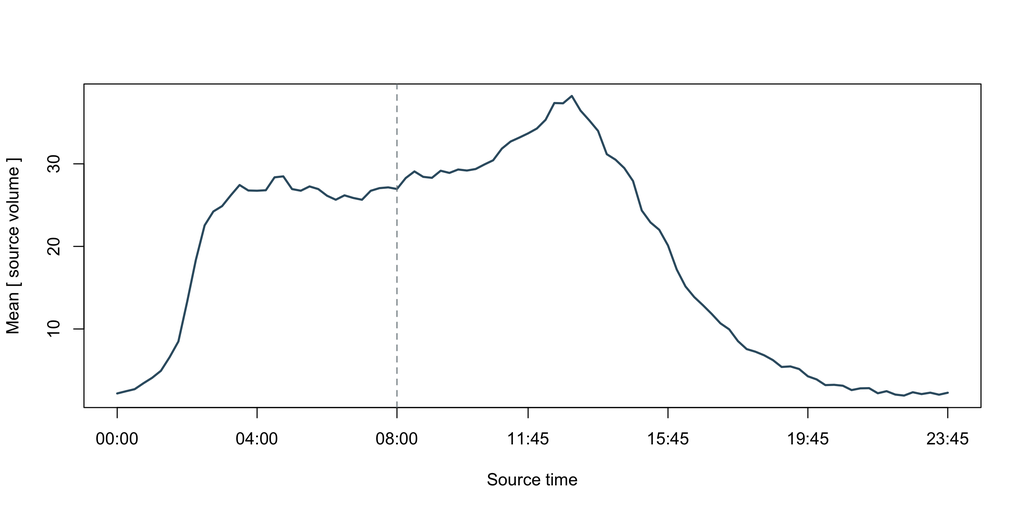

Mean of available road values in each interval. The dashed line marks the selected map time.

```r
trend <- traffic_trend(x)
plot(trend$time,trend$mean,type="l",lwd=2,col="#365c70",xaxt="n",
     xlab="Source time",ylab=paste("Mean [",x$unit,"]"))
at <- unique(round(seq(1,nrow(trend),length.out=7)))
axis(1,at=trend$time[at],labels=sub("^.* ","",trend$label[at]))
abline(v=x$times[index],lty=2,col="#7b858b")
```

```r
peak <- which.max(trend$mean)
```

## Figure and data export

The common `traffic_export()` interface writes PNG/PDF maps and applicable trends, exact selected records, summary and trend tables, source metadata, input/output MD5 checksums and session information. `selected-frame.rds` retains the full input’s color thresholds and unit for inspection; it is not a new input bundle. Existing output directories are refused. The report parameter `export` defaults to false, so normal rendering creates no export folder.

```r
if(params$export) {
  label <- gsub("[^[:alnum:]_-]+","-",x$time_labels[index])
  traffic_export(x,file.path(params$export_dir,label),index=index,
    input_files=c(source="data/source.rds",prepared="data/input.rds"))
}
```

## Basemap source

The figures use the supplied offline OSM-derived context. Basemap build dates identify the context snapshot, independently of the traffic date or simulation day. Generalized map features are suitable for display, not a routable road graph. Map data © [OpenStreetMap contributors](https://www.openstreetmap.org/copyright); basemap extraction uses Protomaps archives distributed as ODbL Produced Works.

| Item | Value |
| --- | --- |
| Region | Supplied context |
| Archive URL | https://build.protomaps.com/20261020.pmtiles |
| Build date | 2026-10-20 |
| Retrieved UTC | 2026-10-22T08:36:35.339013+00:00 |
| Zoom | 11 |
| Recorded bounds (south, west, north, east) | 56.68352, 60.33269, 56.99277, 60.86069 |
| License | OSM-derived Protomaps basemap, ODbL Produced Work |

The source cache preserves the original tile records and geometry checksums. The cache MD5 below identifies the actual bundled copy used for this report.

## Appendix A: preparation implementation

The following code is the source-to-input transformation executed from `prepare.R`. The input cache supplies all objects used by this function.

```r
prepare_example <- function(base=".", source_file="data/source.rds", output_file="data/input.rds") {
  base <- normalizePath(base, mustWork=TRUE)
  source_path <- file.path(base, source_file)
  s <- readRDS(source_path)
  stopifnot(identical(s$schema, "metropolis-volume-frames-v1"))
  roads <- s$road_attributes
  ids <- vapply(s$segments, function(z) as.character(z$id), "")
  stopifnot(identical(ids, as.character(roads$id)))
  roads$road_id <- ids
  roads$geometry <- lapply(s$segments, function(z)
    rbind(c(z$lon1, z$lat1), c(z$lon2, z$lat2)))
  volume <- vapply(s$frames, function(z) as.numeric(z$volume), numeric(length(ids)))
  labels <- vapply(s$frames, function(z) z$time, "")
  stopifnot(identical(labels, s$settings$time_labels), ncol(volume) == 96L,
            all(is.na(volume) | (is.finite(volume) & volume >= 0)))
  flow <- data.frame(road_id=rep(ids, ncol(volume)),
    time=rep(s$settings$times, each=length(ids)), flow=as.vector(volume))
  events <- NULL
  s$settings$provenance$preparation_check <- list(source_segments=length(ids),
    source_frames=length(s$frames), road_frame_values=length(volume),
    added_temporal_aggregation=FALSE, physical_unit_verified=FALSE)
  input <- c(list(schema="trafficmap-input-v1", roads=roads, flow=flow, events=events), s$settings)
  input$provenance$source_cache <- list(file=basename(source_file),
    bytes=unname(file.info(source_path)$size), md5=unname(tools::md5sum(source_path)), schema=s$schema)
  stopifnot(!anyDuplicated(roads$road_id), all(flow$road_id %in% roads$road_id),
            !anyDuplicated(flow[c("road_id", "time")]),
            all(is.na(flow$flow) | (is.finite(flow$flow) & flow$flow >= 0)))
  bdynets::traffic_data(roads=roads, flow=flow, events=events,
    times=input$times, time_labels=input$time_labels, interval_seconds=input$interval_seconds,
    unit=if(is.null(input$unit)) "unit unspecified" else input$unit,
    basemap=input$basemap)
  output <- file.path(base, output_file)
  dir.create(dirname(output), recursive=TRUE, showWarnings=FALSE)
  saveRDS(input, output, compress="xz", version=3)
  invisible(output)
}
if(sys.nframe()==0L) {
  script <- sub("^--file=", "", grep("^--file=", commandArgs(FALSE), value=TRUE))
  if(length(script)!=1L) stop("Rscript entrypoint is required")
  if(!file.exists(script)) script <- gsub("~+~", " ", script, fixed=TRUE)
  prepare_example(dirname(normalizePath(script, mustWork=TRUE)))
  cat("Prepared data/input.rds\n")
}
```

## Appendix B: verification and runtime

```r
knitr::kable(data.frame(Check=names(input$provenance$preparation_check),
  Value=unlist(input$provenance$preparation_check)),caption="Executed preparation checks")
```

Executed preparation checks

|  | Check | Value |
| --- | --- | --- |
| source_segments | source_segments | 720 |
| source_frames | source_frames | 96 |
| road_frame_values | road_frame_values | 69120 |
| added_temporal_aggregation | added_temporal_aggregation | 0 |
| physical_unit_verified | physical_unit_verified | 0 |

```r
knitr::kable(data.frame(File=c("source.rds","input.rds"),
  Bytes=unname(file.info(c("data/source.rds","data/input.rds"))$size),
  MD5=unname(tools::md5sum(c("data/source.rds","data/input.rds")))),
  caption="Actual bundled files")
```

Actual bundled files

| File | Bytes | MD5 |
| --- | --- | --- |
| source.rds | 247616 | 8df13b71231689cdc13c4a823c2306de |
| input.rds | 232068 | d6a6995c7c7981e088b5042c768123c9 |

[session information not shown]